# Atka mackerel assessment 2020

18 October 2020

Annoted data files can be found in the Excel spreadsheet `JM Data files for SC08.xlsx` on [`SPRFMO Teams/sharepoint`](https://southpacificrfmo.sharepoint.com/:f:/s/SPRFMOSC8/EojhefvAJq9KhLVw4AqPUPYBXrW_eBaOTt9-tc3fGwtN_w?e=tek4yE).

Currently, the files resulting from the model runs are not on the Github site, so this `.rmd` file cannot be recompiled without first running the code found in `jjm/assessment/R/SC08.R` to run all the models. Prior to doing this, please compile the latest `jjm/src/jjms.tpl`.

# 1 Model Naming Convention

File naming conventions have been changed to reflect the stock structure hypotheses associated with each run. The `h1` denotes the single-stock hypothesis, while `h2` denotes the two-stock one.

| Model | Description |
| --- | --- |
| Model 16.0b | Same as past year |
| Model 16.0b | Same as past year |
| Model 20.0 | Comparison of new selectivity parameterization (3 parameter double logistic) |
| ———– | ————– |

Make sure that the `jjmR` package is updated with `devtools::install_github("SPRFMO/jjmR")`. `jjms` will need to be updated as well if you decide to run the models on your own.

```r
if(!'devtools' %in% installed.packages()) install.packages('devtools')
#devtools::install_github("SPRFMO/jjmR")
if(!'kableExtra' %in% installed.packages()) install.packages('kableExtra')
```

You’ll need to be in the `Atka’ directory in order for the code here to run.

```r
source("R/prelims.R")
.THEME=mytheme
library(kableExtra)
```

# 2 Model runs

Re-running the 2019 model and comparing the results with this year’s assessment.

## 2.1 Models

### 2.1.1 Biomass

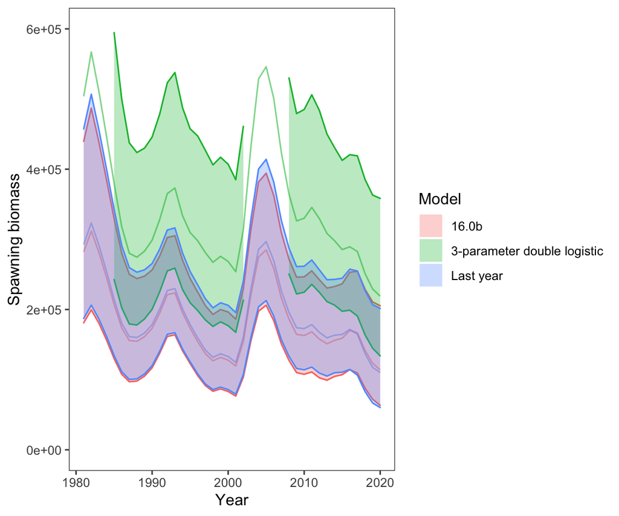

### 2.1.2 Recruitment

[figure not shown]